# Vinhos Tintos - Analise Exploratoria

Eric Inohira Uchimura

6 de fevereiro de 2018

## Análise Exploratória dos vinhos Tintos

A análise deste estudo foi baseado na amostra do estudo realizado pelos autores P. Cortez, A. Cerdeira, F. Almeida, T. Matos and J. Reis. no estudo entitulado: " Modeling wine preferences by data mining from physicochemical properties“. Os dados foram extraidos pelo link disponibilizado pela Udacity (https://s3.amazonaws.com/udacity-hosted-downloads/ud651/wineQualityReds.csv).

A base de dados deste estudo utiliza dados das variantes do vinho portugues chamado “vinho verde”

```r
# importando as bibliotecas necessárias para este estudo

library(ggplot2)
library(gridExtra)
library(GGally)
library(RColorBrewer)
library(mosaic)
library (grid)
library(corrplot)
# Setando o diretório para o local onde o arquivo foi salvo

setwd("C:/Users/eric.uchimura/OneDrive/Udacity/RStudio/Projeto - Vinho/")

# carregando a base de dados

baseVinho <- read.csv('wineQualityReds.csv')
```

## Análises Iniciais

Verificaremos os nomes das colunas e as primeiras variaveis para ter um primeiro contato com os dados

```r
names(baseVinho)
```

```
##  [1] "X"                    "fixed.acidity"        "volatile.acidity"
##  [4] "citric.acid"          "residual.sugar"       "chlorides"
##  [7] "free.sulfur.dioxide"  "total.sulfur.dioxide" "density"
## [10] "pH"                   "sulphates"            "alcohol"
## [13] "quality"
```

```r
head(baseVinho)
```

```
##   X fixed.acidity volatile.acidity citric.acid residual.sugar chlorides
## 1 1           7.4             0.70        0.00            1.9     0.076
## 2 2           7.8             0.88        0.00            2.6     0.098
## 3 3           7.8             0.76        0.04            2.3     0.092
## 4 4          11.2             0.28        0.56            1.9     0.075
## 5 5           7.4             0.70        0.00            1.9     0.076
## 6 6           7.4             0.66        0.00            1.8     0.075
##   free.sulfur.dioxide total.sulfur.dioxide density   pH sulphates alcohol
## 1                  11                   34  0.9978 3.51      0.56     9.4
## 2                  25                   67  0.9968 3.20      0.68     9.8
## 3                  15                   54  0.9970 3.26      0.65     9.8
## 4                  17                   60  0.9980 3.16      0.58     9.8
## 5                  11                   34  0.9978 3.51      0.56     9.4
## 6                  13                   40  0.9978 3.51      0.56     9.4
##   quality
## 1       5
## 2       5
## 3       5
## 4       6
## 5       5
## 6       5
```

Esta base possui 12 variáveis (consideramos a primeira coluna “X” como um ID). 11 variáveis são baseadas nos tetes físico-quimicos - Acidez voláil, acidex fixa, acidez citrica, açucar, cloretos, dioxidos livres, total de dioxido, densidade, ph, sulfato, alcool. Apenas uma variavel (Qualidade) é baseado na sensação do avaliador que é uma nota que vai de zero a 10.

## Análise individual das variaveis

### Qualidade

Ao verificar a frequencia das avaliações temos:

```r
table (baseVinho$quality)
```

```
##
##   3   4   5   6   7   8
##  10  53 681 638 199  18
```

```r
summary(baseVinho$quality)
```

```
##    Min. 1st Qu.  Median    Mean 3rd Qu.    Max.
##   3.000   5.000   6.000   5.636   6.000   8.000
```

```r
#Classificando os vinhos

baseVinho$classificacao <- ifelse(baseVinho$quality<5,
                                  'sangue de boi',
                                  ifelse(baseVinho$quality <7,
                                         'bom',
                                         'excelente'))
baseVinho$classificacao <- ordered(baseVinho$classificacao,
                                   levels = c('sangue de boi',
                                              'bom',
                                              'excelente'))
```

Analisaremos cada variavel com o histograma de frequencia.

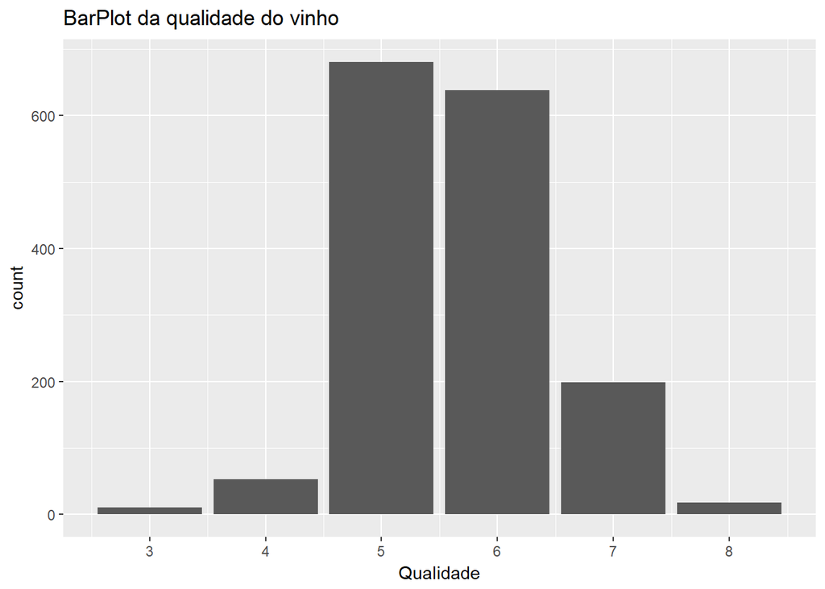

```r
# Plotagem do histograma da variavel qualidade
qplot(baseVinho$quality,
      geom = "bar") +
    xlab("Qualidade") +
    ggtitle("BarPlot da qualidade do vinho") +
  scale_x_continuous(breaks=seq(3, 8, 1))
```

Conclui-se que nao temos vinhos com ota abaixo de 3 e maiores que 8. Os extremos de vinhos ruins e extraordinários não existem nesta base. Verifica-se por meio do grafico uma concentração (maior que 600) de vinhos com nota 5 e 6.

### Acidez Fixa (fixed acidity)

```r
# verificar a população nos quartis
summary(baseVinho$fixed.acidity)
```

```
##    Min. 1st Qu.  Median    Mean 3rd Qu.    Max.
##    4.60    7.10    7.90    8.32    9.20   15.90
```

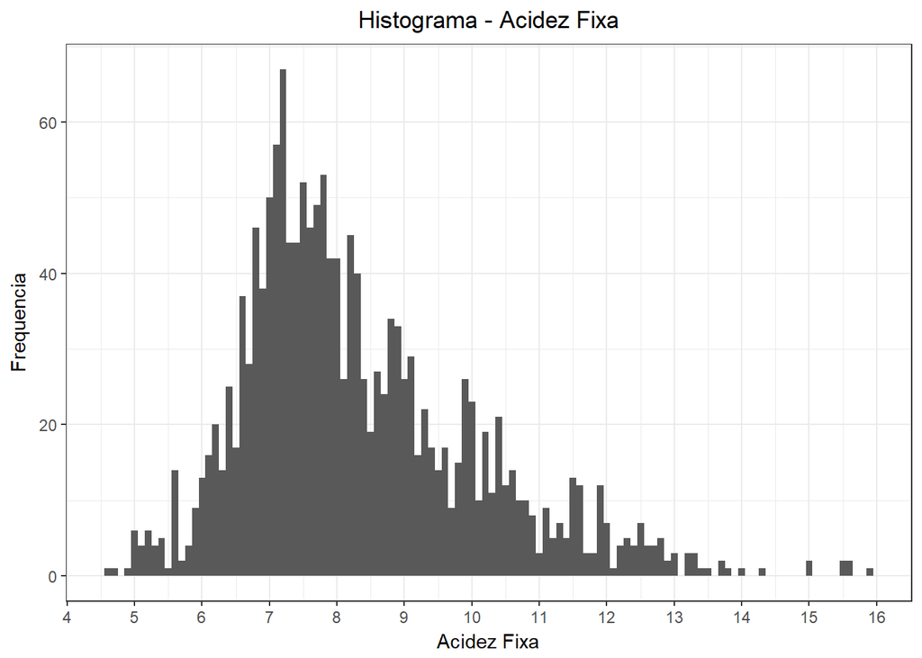

```r
# grafico de histograma da acidez

ggplot(baseVinho, aes(fixed.acidity)) +
  geom_histogram(binwidth = 0.1) +
  ggtitle('Histograma - Acidez Fixa')+
  theme_bw() +
  theme(plot.title = element_text(hjust = 0.5))+
  xlab('Acidez Fixa') +
  ylab('Frequencia') +
  scale_x_continuous(breaks=seq(0, 16, 1))
```

```r
# scale_x_continuous(breaks=c(4, 5, 6, 7, 8, 9, 10, 11, 12, 13, 14, 15, 16))
```

Grande concentração dos dados com acidez fixa igual a 8 (mediana) com marcante presença de outliers acima de 14.

### Acidez Volátil (volatile accidity)

Corresponde a quantidadae de acido acético no vinho que em níveis altos levam o vinho a ter um gosto de vinagre

```r
# analise da populaçao nos quartis de acidez volatil
summary(baseVinho$volatile.acidity)
```

```
##    Min. 1st Qu.  Median    Mean 3rd Qu.    Max.
##  0.1200  0.3900  0.5200  0.5278  0.6400  1.5800
```

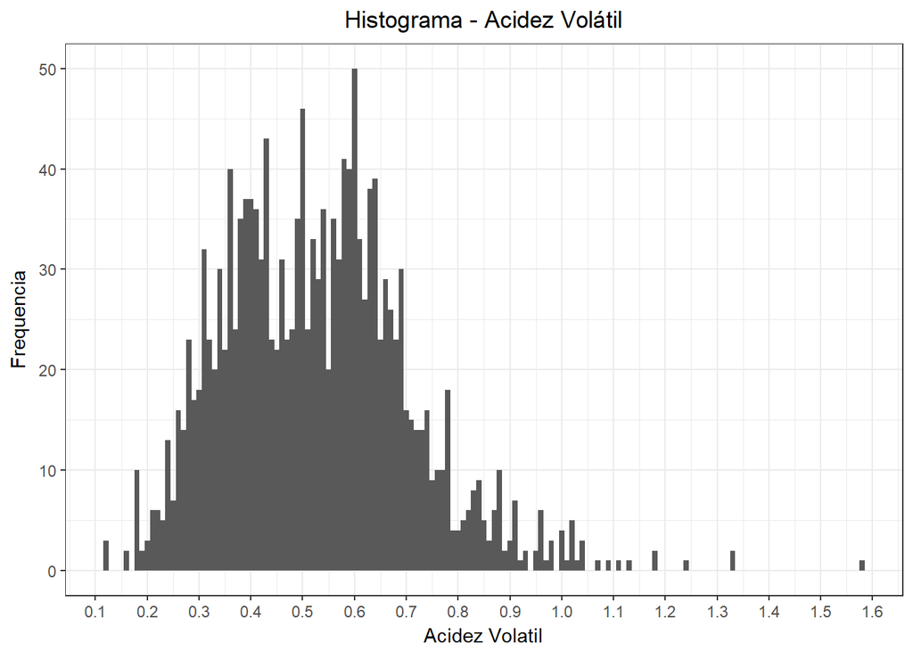

```r
# plota o histograma de acidez volátil
ggplot(baseVinho, aes(volatile.acidity)) +
  geom_histogram(binwidth = 0.01) +
  ggtitle('Histograma - Acidez Volátil')+
  theme_bw() +
  theme(plot.title = element_text(hjust = 0.5))+
  xlab('Acidez Volatil') +
  ylab('Frequencia')+
  scale_x_continuous(breaks=seq(0, 1.6, 0.1))
```

Distribuição bimodal em torno do valor 0.4 e 0,6. Outliers com valores acima de 1,2.

### Acido Cítrico - Citric Acid

Encontrado em menor quantidade leva um sabor de frescor (freshness) ao vinho

```r
# verifica a população nos quartis do acido citrico
summary(baseVinho$citric.acid)
```

```
##    Min. 1st Qu.  Median    Mean 3rd Qu.    Max.
##   0.000   0.090   0.260   0.271   0.420   1.000
```

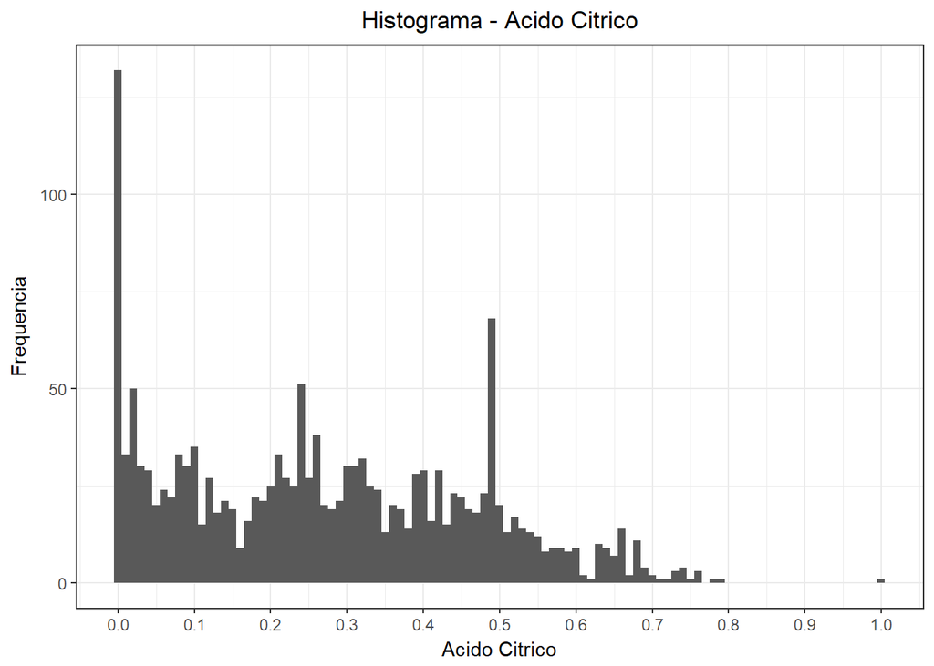

```r
#plota histograma do acido citrico
ggplot(baseVinho, aes(citric.acid)) +
  geom_histogram(binwidth = 0.01) +
  ggtitle('Histograma - Acido Citrico')+
  theme_bw() +
  theme(plot.title = element_text(hjust = 0.5))+
  xlab('Acido Citrico') +
  ylab('Frequencia') +
  scale_x_continuous(breaks=seq(0, 1.0, 0.1))
```

Verifica-se que grande parte dos vinhos o valor oscila entre 0.00 a 0.75 (o 3o quartil está em 0.42). Graficamente verifica-se que o 1.0 é um caso isolado (outlier). Verificamos com fica o histograma, limitando ao quartil 0.99.

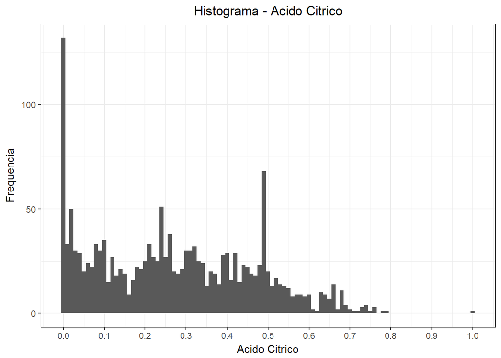

```r
#plota histograma do acido citrico limitando os quartis.
ggplot(baseVinho, aes(citric.acid)) +
  geom_histogram(binwidth = 0.01) +
  xlim(-0.01, quantile(baseVinho$citric.acid, 0.99))+
  ggtitle('Histograma - Acido Citrico')+
  theme_bw() +
  theme(plot.title = element_text(hjust = 0.5))+
  xlab('Acido Citrico') +
  ylab('Frequencia')+
  scale_x_continuous(breaks=seq(0, 1.0, 0.1))
```

Grande quantidade de vinhos sem a presença de acido citrico. Erro de medição?

### Açucar residual - Residual sugar

Quantidade de açucar residual que é encontrado após a fermentação. Dificilmente encontra-se vinhos com menos de uma grama por litro e mais de 45 gramas por litro

```r
#população do acucar residual nos quartis
summary(baseVinho$residual.sugar)
```

```
##    Min. 1st Qu.  Median    Mean 3rd Qu.    Max.
##   0.900   1.900   2.200   2.539   2.600  15.500
```

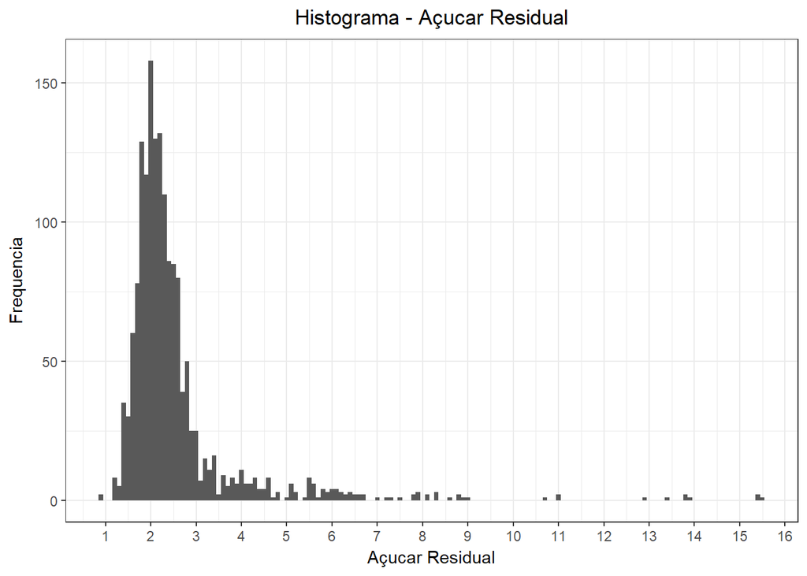

```r
#plota histograma do açucar residual
ggplot(baseVinho, aes(residual.sugar)) +
  geom_histogram(binwidth = 0.1) +
  ggtitle('Histograma - Açucar Residual')+
  theme_bw() +
  theme(plot.title = element_text(hjust = 0.5))+
  xlab('Açucar Residual') +
  ylab('Frequencia') +
  scale_x_continuous(breaks=seq(0, 16, 1))
```

Grande concentração com valores de 2.0. Verifica-se pelo grafico de histograma do açucar residual que valores acima de 6 ficam dispersos na frequencia. Vamos verificar utilizar a transformação log10.

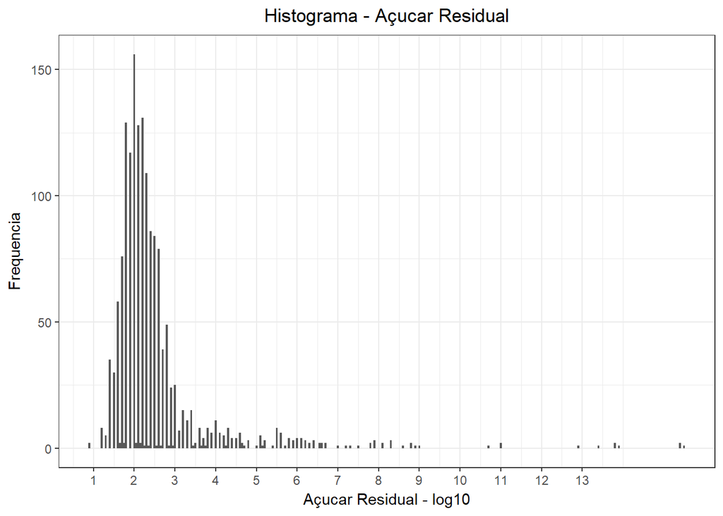

```r
#plota histograma do açucar residual
ggplot(baseVinho, aes(residual.sugar)) +
  geom_histogram(binwidth = 0.05) +
  scale_x_log10()+
  ggtitle('Histograma - Açucar Residual')+
  theme_bw() +
  theme(plot.title = element_text(hjust = 0.5))+
  xlab('Açucar Residual - log10') +
  ylab('Frequencia') +
  scale_x_continuous(breaks=seq(0, 13, 1))
```

Com a transformação log10 a distribuição ficou na mesma. Concentração no nivel 2, com outliers até o 16.

### Cloreto - chlorides

Quantidade de sal no vinho

```r
#verifica a populaçao dos cloretos nos quartis
summary(baseVinho$chlorides)
```

```
##    Min. 1st Qu.  Median    Mean 3rd Qu.    Max.
## 0.01200 0.07000 0.07900 0.08747 0.09000 0.61100
```

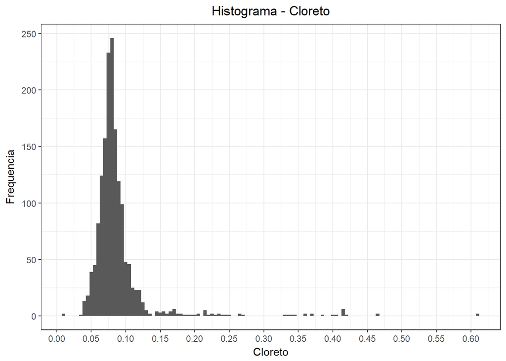

```r
#plota o histograma do cloreto
ggplot(baseVinho, aes(chlorides)) +
  geom_histogram(binwidth = 0.005) +
  ggtitle('Histograma - Cloreto')+
  theme_bw() +
  theme(plot.title = element_text(hjust = 0.5))+
  xlab('Cloreto') +
  ylab('Frequencia') +
  scale_x_continuous(breaks=seq(0, 0.7, 0.05))
```

Encontra-se poucos valores próximo de 0 e poucos valores com valor maior que 0.2. Plotamos a base utilizando a transformação log10. Como a frequencia está concentrada nos valores menor que 0.1, tentamos “linearizar” utilizando uma escala logaritimica

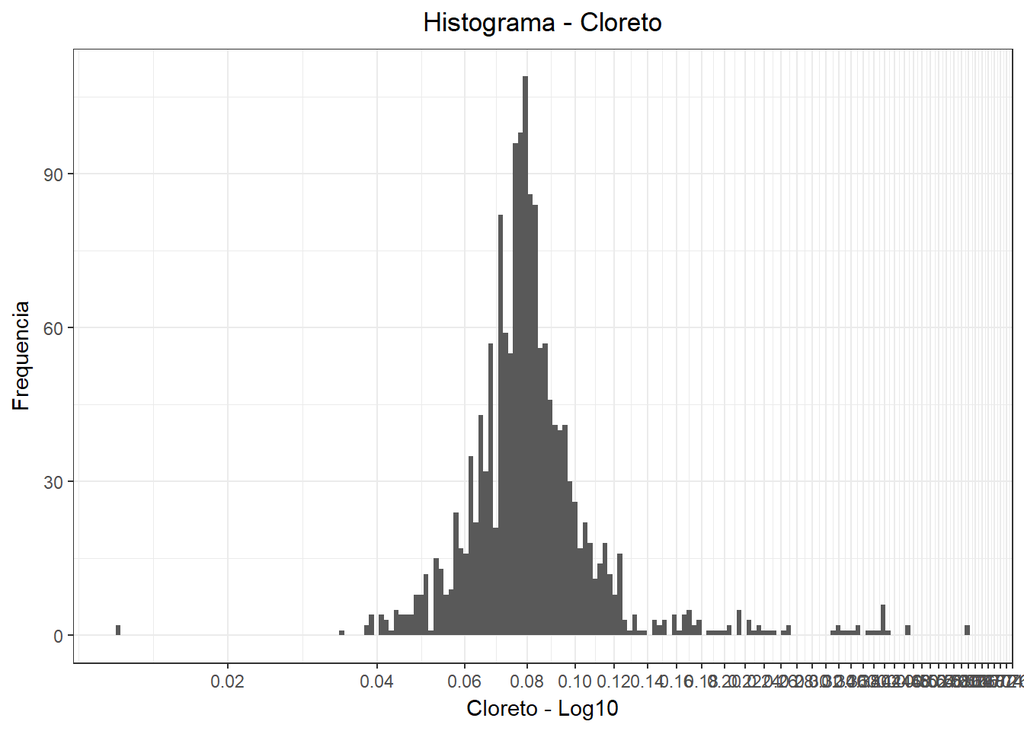

```r
#plota histograma do cloreto utilizando transformação log10
ggplot(baseVinho, aes(chlorides)) +
  geom_histogram(binwidth = 0.01) +
  scale_x_log10(breaks=seq(0, 1, 0.02)) +
  ggtitle('Histograma - Cloreto')+
  theme_bw() +
  theme(plot.title = element_text(hjust = 0.5))+
  xlab('Cloreto - Log10') +
  ylab('Frequencia')
```

Após transformação verificamos que o histograma forma um formato de sino (paramétrica).

### Dióxido de enxofre Livre - Free Sulfur dioxide

Previne aumento na reprodução das microbacterias e da oxidação do vinho

```r
# população do dioxido de enxofre livre nos quartis
summary(baseVinho$free.sulfur.dioxide)
```

```
##    Min. 1st Qu.  Median    Mean 3rd Qu.    Max.
##    1.00    7.00   14.00   15.87   21.00   72.00
```

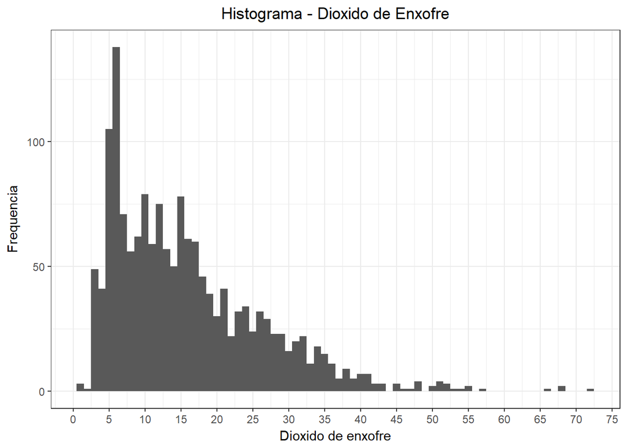

```r
#plota o histograma de dioxido de enxofre
ggplot(baseVinho, aes(free.sulfur.dioxide)) +
  geom_histogram(binwidth = 1) +
  ggtitle('Histograma - Dioxido de Enxofre')+
  theme_bw() +
  theme(plot.title = element_text(hjust = 0.5))+
  xlab('Dioxido de enxofre') +
  ylab('Frequencia') +
 scale_x_continuous(breaks=seq(0, 80, 5))
```

Verifica-se uma grande concentração com valores abaixo de 20.

Tentaremos aplicar a transformação log10 com o intuito de normalizar a variavel.

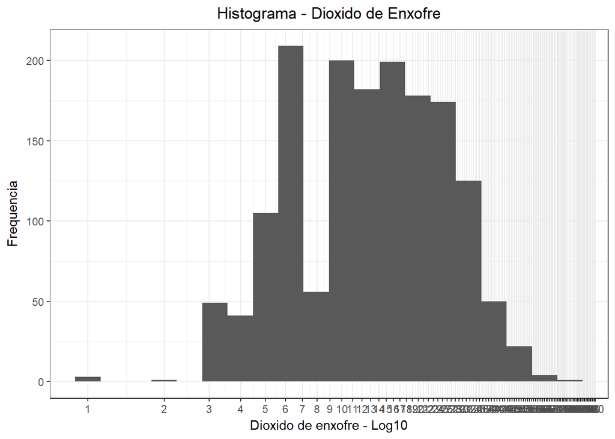

```r
#plota o histograma de dioxido de enxofre com transformação logaritimica
ggplot(baseVinho, aes(free.sulfur.dioxide)) +
  geom_histogram(binwidth = 0.1) +
  scale_x_log10(breaks=seq(0, 100, 1)) +
  ggtitle('Histograma - Dioxido de Enxofre')+
  theme_bw() +
  theme(plot.title = element_text(hjust = 0.5))+
  xlab('Dioxido de enxofre - Log10') +
  ylab('Frequencia')
```

Verifica-se que a transformação não formou um “sino” tendo 2 picos e um “buraco” nos valores proximos

Tentaremos a transformação sqrt para normalizar a variavel.

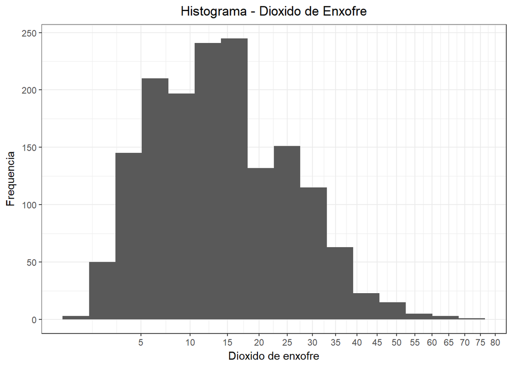

```r
#plota o histograma do dioxido de enxofre utilizando a transformação sqrt
ggplot(baseVinho, aes(free.sulfur.dioxide)) +
  geom_histogram(binwidth = 0.5) +
  ggtitle('Histograma - Dioxido de Enxofre')+
  scale_x_sqrt(breaks=seq(0, 80, 5)) +
  theme_bw() +
  theme(plot.title = element_text(hjust = 0.5))+
  xlab('Dioxido de enxofre') +
  ylab('Frequencia')
```

Mesmo com as 2 transformaçoes, verificamos que não houve sucesso em “normalizar” essa variável. O formato de sino ficou desproporcional no lado direito, não ficando simétrico.

### Dióxido de enxofre total - Total sulfur dioxide

Imperceptível em baixas concentrações, mas concentrações elevadas fica evidente no cheiro e no sabor do vinho

```r
#população do dioxido de enxofre total nos quartis
summary(baseVinho$total.sulfur.dioxide)
```

```
##    Min. 1st Qu.  Median    Mean 3rd Qu.    Max.
##    6.00   22.00   38.00   46.47   62.00  289.00
```

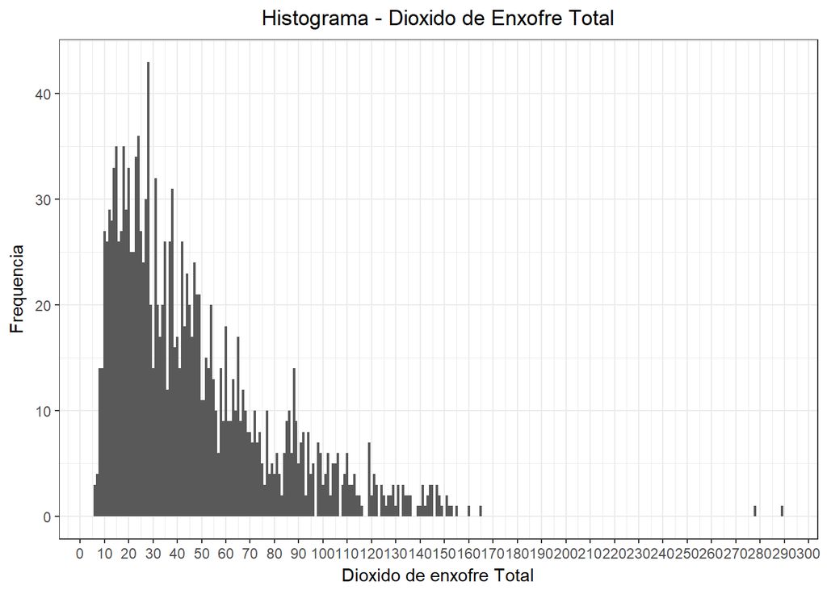

```r
#plota histograma do dioxido de enxofre total
ggplot(baseVinho, aes(total.sulfur.dioxide)) +
  geom_histogram(binwidth = 1) +
  ggtitle('Histograma - Dioxido de Enxofre Total')+
  theme_bw() +
  theme(plot.title = element_text(hjust = 0.5))+
  xlab('Dioxido de enxofre Total') +
  ylab('Frequencia') +
  scale_x_continuous(breaks=seq(0, 300, 10))
```

Verifica-se concentração até o valor 100 com outliers com valores de 280 a 300.

Em escala logaritimica

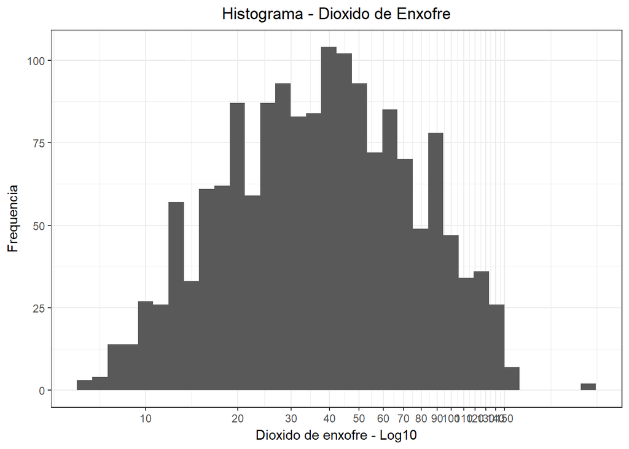

```r
#plota o histograma do dioxido de enxofre em escala log10
ggplot(baseVinho, aes(total.sulfur.dioxide)) +
  geom_histogram(binwidth = 0.05) +
  scale_x_log10(breaks=seq(0, 150, 10)) +
  ggtitle('Histograma - Dioxido de Enxofre')+
  theme_bw() +
  theme(plot.title = element_text(hjust = 0.5))+
  xlab('Dioxido de enxofre - Log10') +
  ylab('Frequencia')
```

Verfica-se dois picos na regial central, sem simetria para o sino. Verificamos agora a transformação sqrt.

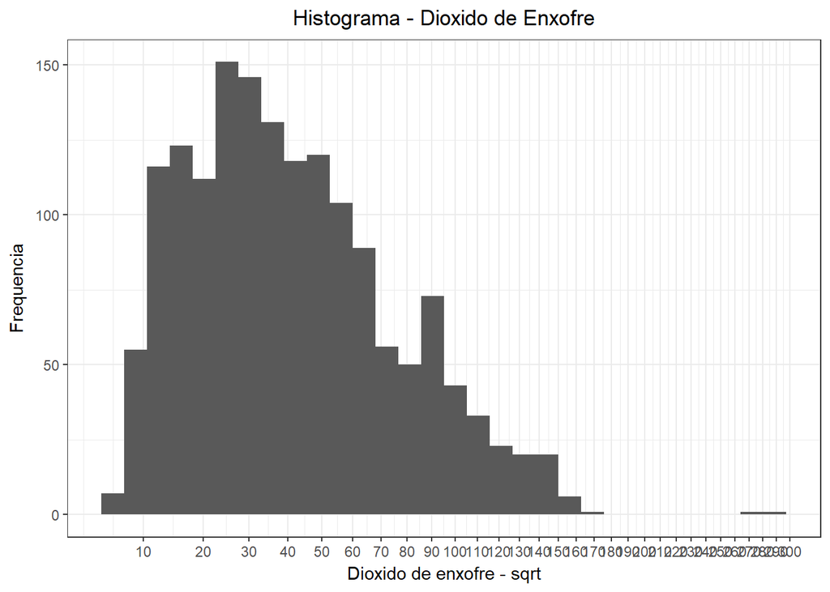

```r
#plota histograma de dioxido de enxofre na escala sqrt
ggplot(baseVinho, aes(total.sulfur.dioxide)) +
  geom_histogram(binwidth = 0.5) +
  scale_x_sqrt(breaks=seq(0, 300, 10)) +
  ggtitle('Histograma - Dioxido de Enxofre')+
  theme_bw() +
  theme(plot.title = element_text(hjust = 0.5))+
  xlab('Dioxido de enxofre - sqrt') +
  ylab('Frequencia')
```

Por visualização a tranformação em log10 torna-se mais adequada, porém não é visivel a normalização dessa variavel, ou seja, um histograma em formato de sino, simetrico no meio.

### Densidade

Densidade do vinho é aproximadamente a mesma densidade da água. A distorção da-se-à pela quantidade de alcool e açucar no vinho

```r
#população dos quartis da densidade
summary(baseVinho$density)
```

```
##    Min. 1st Qu.  Median    Mean 3rd Qu.    Max.
##  0.9901  0.9956  0.9968  0.9967  0.9978  1.0037
```

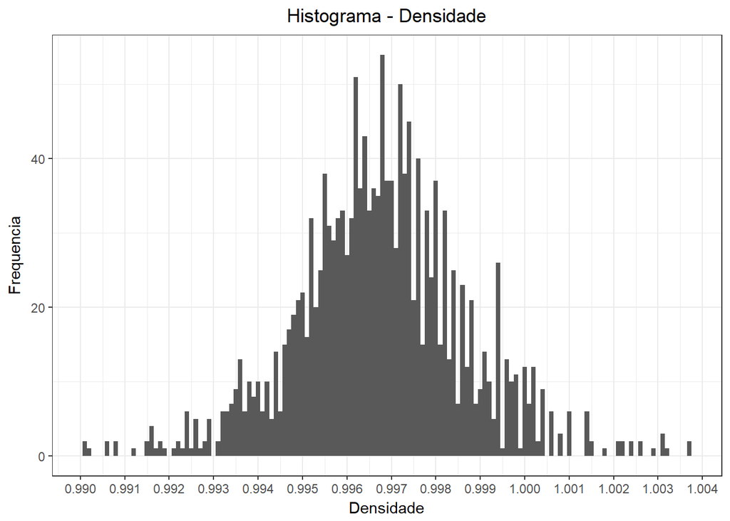

```r
# plota o histograma da densidade
ggplot(baseVinho, aes(density)) +
  geom_histogram(binwidth = 0.0001) +
  ggtitle('Histograma - Densidade')+
  theme_bw() +
  theme(plot.title = element_text(hjust = 0.5))+
  xlab('Densidade') +
  ylab('Frequencia') +
  scale_x_continuous(breaks=seq(0, 1.1, 0.001))
```

Densidade bem distribuida, sem necessidade de transformações.

### pH

Verifica a aciddes do vinho numa escala de 0 a 14. (0 muito ácido - 14 muito básico) Maioria dos vinhos entre 3 e 4

```r
#população do ph nos quartis
summary(baseVinho$pH)
```

```
##    Min. 1st Qu.  Median    Mean 3rd Qu.    Max.
##   2.740   3.210   3.310   3.311   3.400   4.010
```

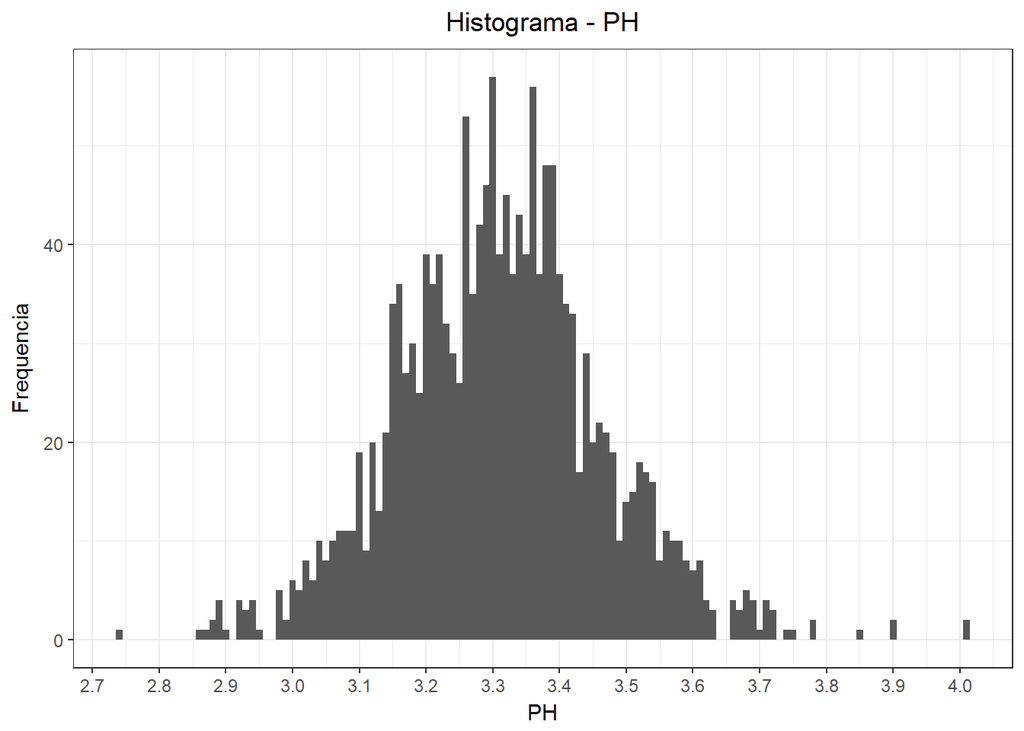

```r
#histograma do ph
ggplot(baseVinho, aes(pH)) +
  geom_histogram(binwidth = 0.01) +
  ggtitle('Histograma - PH')+
  theme_bw() +
  theme(plot.title = element_text(hjust = 0.5))+
  xlab('PH') +
  ylab('Frequencia') +
  scale_x_continuous(breaks=seq(0, 5, 0.1))
```

Observamos uma concentração com PH=3.3.

### Sulfato

Aditivo que contribui na produção de SO2 (dioxido de enxofre) que atua com o antioxidante e anti-bactericida

```r
#população do sulfato nos quartis
summary(baseVinho$sulphates)
```

```
##    Min. 1st Qu.  Median    Mean 3rd Qu.    Max.
##  0.3300  0.5500  0.6200  0.6581  0.7300  2.0000
```

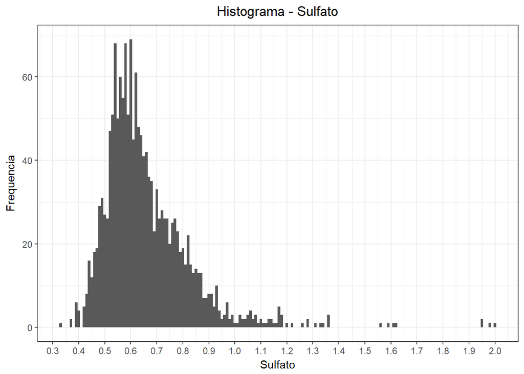

```r
#histograma do sulfato
ggplot(baseVinho, aes(sulphates)) +
  geom_histogram(binwidth = 0.01) +
  ggtitle('Histograma - Sulfato')+
  theme_bw() +
  theme(plot.title = element_text(hjust = 0.5))+
  xlab('Sulfato') +
  ylab('Frequencia') +
 scale_x_continuous(breaks=seq(0, 2, 0.1))
```

Observa-se uma concentração até o valor 0.9,1.0 com alguns outliers na faixa enre 1.9 e 2.0.

Aplicando a transformação log10, tem-se:

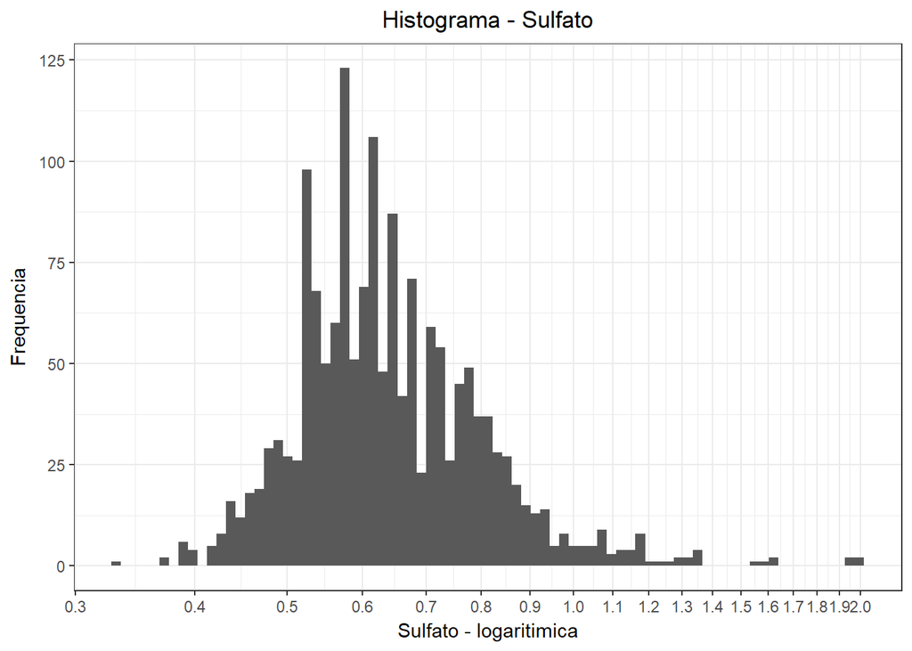

```r
#histograma do sulfato, utilizando o transformação logaritimica
ggplot(baseVinho, aes(sulphates)) +
  geom_histogram(binwidth = 0.01) +
  scale_x_log10(breaks=seq(0, 2, 0.1)) +
  ggtitle('Histograma - Sulfato')+
  theme_bw() +
  theme(plot.title = element_text(hjust = 0.5))+
  xlab('Sulfato - logaritimica') +
  ylab('Frequencia')
```

Novamente temos uma concentração entre 0.5 e 1.0 com outliers na casa dos 2.0.

### Alcool

% de alcool contida no vinho.

```r
#população do alcool nos quartis
summary(baseVinho$alcohol)
```

```
##    Min. 1st Qu.  Median    Mean 3rd Qu.    Max.
##    8.40    9.50   10.20   10.42   11.10   14.90
```

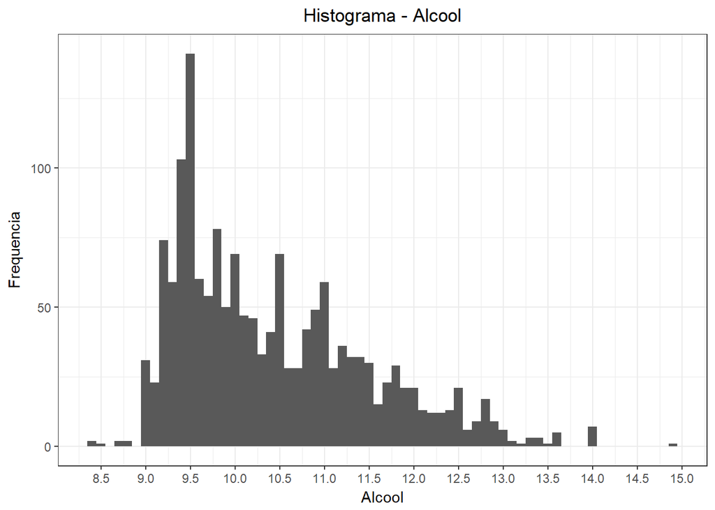

```r
#histograma do alcool
ggplot(baseVinho, aes(alcohol)) +
  geom_histogram(binwidth = 0.1) +
  ggtitle('Histograma - Alcool')+
  theme_bw() +
  theme(plot.title = element_text(hjust = 0.5))+
  xlab('Alcool') +
  ylab('Frequencia') +
  scale_x_continuous(breaks=seq(0, 15, 0.5))
```

Encontramos valores distibuidos entre 9 e 13 com pico em 9.5 e alguns outros picos entre 10, 10.5 e 11.

## Análise Univariada

### Qual a estrutura dos seus dados?

População contém 1599 observações com 12 diferentes atributos. Uma é categórica (qualidade) e outras numericas que indicam as propriedades quimicas do vinho.

### Quais as caracteristicas mais relevantes na sua população?

A variavel dependente, qualidade. As outras 11 variáveis são as independentes na quais posteriormente neste estudo queremos verificar se há alguma relação entre as variáveis independentes com a qualidade do vinho.

### Quais outras caracteristicas na base você acha que vai ajudar na investigação?

Somente conseguiremos responder a esta pergunta depois de realizar os testes de correlação entre duas ou mais variáveis afetam a qualidade.

### você criou novas variáveis na base?

Sim. Classificamos melhor a qualidade com 3 categorias do vinho: notas: menor que 5 = “sangue de boi” notas: 5~7 = “bom pro dia a dia” notas: 7 pra cima = “excelente”

### Das variaveis que foram investigadas, houve alguma distribuição não-usual? Alguma operação para ajustar os dados? se sim você fez?

Açucar Residual foram utilizadas o quartil de 0.95. Cloreto foi utilizado o quartil 0.95 no meio. Dioxido de enxofre foi utilizado a transformação raiz quadrada Dioxido de enxofre total foi utilizado a transforação logaritimica de base 10.

## Análise com duas variáveis

INicialmente pode-se rodar o ggpairs para verificar algum relacionamento entre as variaveis dependentes com a independente de modo geral.Como a base possui poucas observações, não vi necessidade de utilizar uma amostra da população.

```r
#set.seed(69)

#amostragem <- baseVinho[sample(1:length(baseVinho$quality), 100), ]

# verifica a correlação e o grafico de dispersão de todas as variaveis,
# confrontando-os um a um
#ggpairs(baseVinho,
#        lower = list(continuous = wrap("points", shape = I('.'))),
#        upper = list(combo = wrap("box", outlier.shape = I('.'))))
```

Como a população possui 13 variaveis o resultado do ggpair não fica visivel neste tamanho.

```r
#verificamos o que é numerico e o que não é
sapply (baseVinho, is.numeric)
```

```
##                    X        fixed.acidity     volatile.acidity
##                 TRUE                 TRUE                 TRUE
##          citric.acid       residual.sugar            chlorides
##                 TRUE                 TRUE                 TRUE
##  free.sulfur.dioxide total.sulfur.dioxide              density
##                 TRUE                 TRUE                 TRUE
##                   pH            sulphates              alcohol
##                 TRUE                 TRUE                 TRUE
##              quality        classificacao
##                 TRUE                FALSE
```

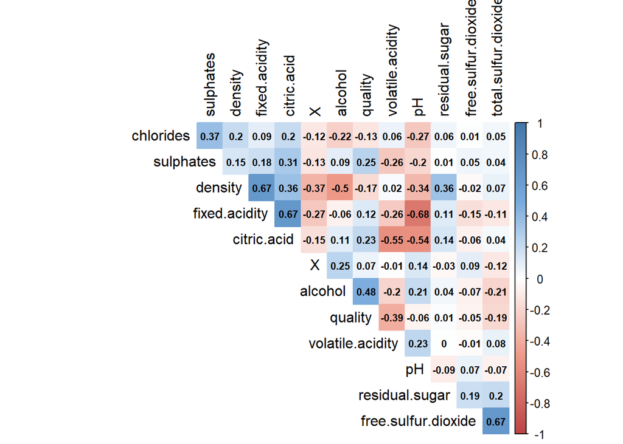

```r
#retira-se a primeira coluna pois é apenas um contador
baseVinho$x <- NULL

#coloca-se apenas a base numerica na variavel baseVinhoNum
baseVinhoNum <- baseVinho[, sapply(baseVinho, is.numeric)]


# calcula tabela com as correlações.
col <- colorRampPalette(c("#BB4444", "#EE9988", "#FFFFFF", "#77AADD", "#4477AA"))
corrplot(cor(baseVinhoNum), method = "color", col = col(200),
         type = "upper", order = "hclust", number.cex = .7,
         addCoef.col = "black", # Add coefficient of correlation
         tl.col = "black", tl.srt = 90, # Text label color and rotation
         # Combine with significance
         sig.level = 0.01, insig = "blank",
         # hide correlation coefficient on the principal diagonal
         diag = FALSE)
```

Baseado nesta tabela, as maiores correlações com a qualidade do vinho se dá com o alcool (0.476), acidez volatil (-0.391), sulfato (0.251) o acido citrico (0.226).

```r
# correlação entre as variaveis com a qualidade
c1 <- cor.test(baseVinho$fixed.acidity,
               baseVinho$quality,
               method='pearson')$estimate
c2 <- cor.test(baseVinho$volatile.acidity,
             baseVinho$quality,
             method='pearson')$estimate
c3 <- cor.test(baseVinho$citric.acid,
             baseVinho$quality,
             method='pearson')$estimate
c4 <- cor.test(log10(baseVinho$residual.sugar),
             baseVinho$quality,
             method='pearson')$estimate
c5 <- cor.test(baseVinho$residual.sugar,
             baseVinho$quality,
             method='pearson')$estimate
c6 <- cor.test(log10(baseVinho$chlorides),
             baseVinho$quality,
             method='pearson')$estimate
c7 <- cor.test(baseVinho$chlorides,
             baseVinho$quality,
             method='pearson')$estimate
c8 <- cor.test(baseVinho$free.sulfur,
             baseVinho$quality,
             method='pearson')$estimate
c9 <- cor.test(baseVinho$total.sulfur.dioxide,
             baseVinho$quality,
             method='pearson')$estimate
c10 <- cor.test(baseVinho$density,
              baseVinho$quality,
              method='pearson')$estimate
c11 <- cor.test(baseVinho$pH,
              baseVinho$quality,
              method='pearson')$estimate
c12 <- cor.test(log10(baseVinho$sulphates),
              baseVinho$quality,
              method='pearson')$estimate
c13 <- cor.test(baseVinho$sulphates,
              baseVinho$quality,
              method='pearson')$estimate
c14 <- cor.test(baseVinho$alcohol,
              baseVinho$quality,
              method='pearson')$estimate
#tabulação dos resultados
tabela.corr <- c(c1, c2, c3, c4, c5, c6, c7, c8, c9, c10, c11, c12, c13, c14)
names(tabela.corr) <-c ('acidez fixa',
                        'acidez volatil',
                        'acidez citrica',
                        'log ac.Res.',
                        'ac.Res',
                        'log Clor',
                        'clor',
                        'diox.enx.liv',
                        'diox.enx.t',
                        'densidade',
                        'ph',
                        'log sul.',
                        'sulfato',
                        'alcool')

tabela.corr
```

```
##    acidez fixa acidez volatil acidez citrica    log ac.Res.         ac.Res
##     0.12405165    -0.39055778     0.22637251     0.02353331     0.01373164
##       log Clor           clor   diox.enx.liv     diox.enx.t      densidade
##    -0.17613996    -0.12890656    -0.05065606    -0.18510029    -0.17491923
##             ph       log sul.        sulfato         alcool
##    -0.05773139     0.30864193     0.25139708     0.47616632
```

Mesmo com as trasformações o aumento da correlação das transformações foram irrelevantes. Podemos concluir que um bom vinho tem correlação com as variaveis: alcool, acidez volátil, sulfato e acido citrico.

Surpreendentemente, o PH não teve correlação com a Qualidade apesar de sabermos que o PH é quimicamente e influenciado pela quantidade de acidez e acidos em uma substancia. Prova disso é que encontramos uma alta correlação entre PH e Acidez fixa (-0.68), PH e acido citrico (-0.54).

Vamos plotar os graficos para corroborar com essas afirmações de correlação.

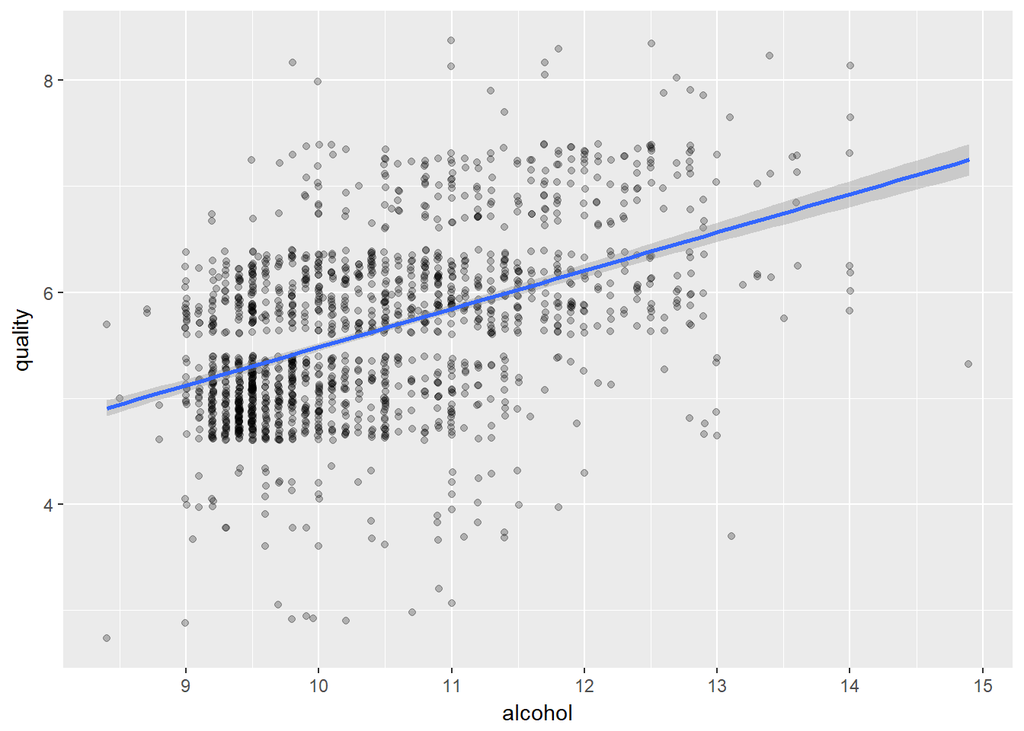

```r
# plota relação entre alcool e qualidade
ggplot(baseVinho, aes(x = alcohol, y = quality)) +
  geom_jitter(alpha = 0.25) +
  geom_smooth(method = "lm")+
  scale_x_continuous(breaks=seq(0, 15, 1))
```

Verfica-se pela linha azul que na medida que há um aumento do alcool a qualidade também melhora com correlação igual a 0.48.

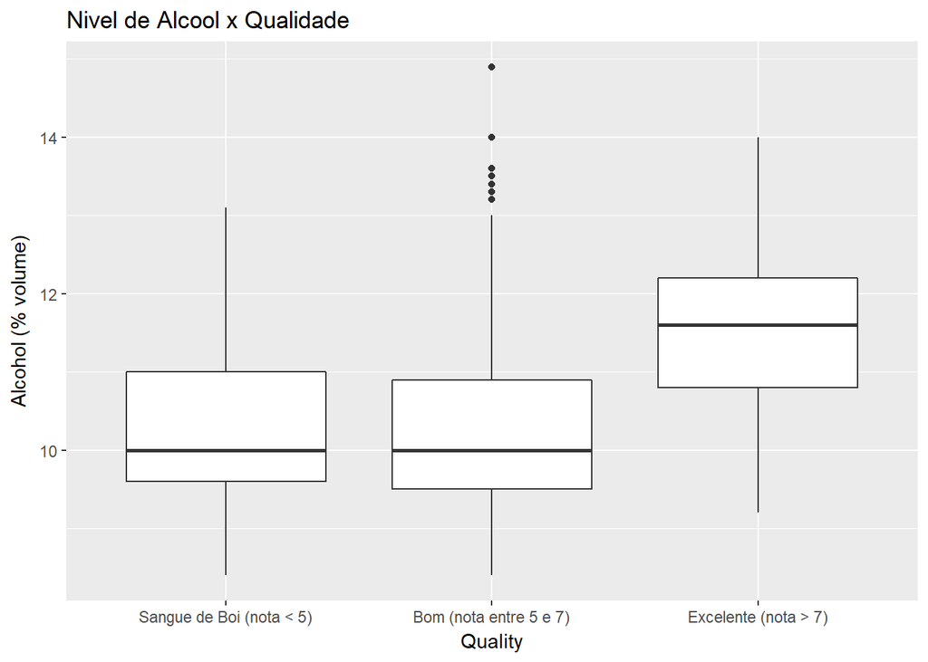

```r
# plotagem do qualidade x alcool separando por classificação
ggplot(data = baseVinho) +
  geom_boxplot(aes(x = classificacao,
           y = alcohol)) +
  scale_x_discrete(labels = c("sangue de boi" = "Sangue de Boi (nota < 5)",
                                        "bom" = "Bom (nota entre 5 e 7)",
                                  "excelente" = "Excelente (nota > 7)")) +
  ggtitle('Nivel de Alcool x Qualidade') +
  xlab('Quality') +
  ylab('Alcohol (% volume)')
```

Nota-se mais claramente pelo bloxpot que os vinhos de excelente qualidade possui maior quantidade de alcool (Mediana 11.6, media 11.5, q1 = 10.8, q3 = 12.2) como vemos na tabela a seguir.

```r
# estatistica dos boxplox
favstats(~baseVinho$alcohol | baseVinho$classificacao, data = baseVinho)
```

```
##   baseVinho$classificacao min   Q1 median   Q3  max     mean        sd
## 1           sangue de boi 8.4  9.6   10.0 11.0 13.1 10.21587 0.9181778
## 2                     bom 8.4  9.5   10.0 10.9 14.9 10.25272 0.9723537
## 3               excelente 9.2 10.8   11.6 12.2 14.0 11.51805 0.9981532
##      n missing
## 1   63       0
## 2 1319       0
## 3  217       0
```

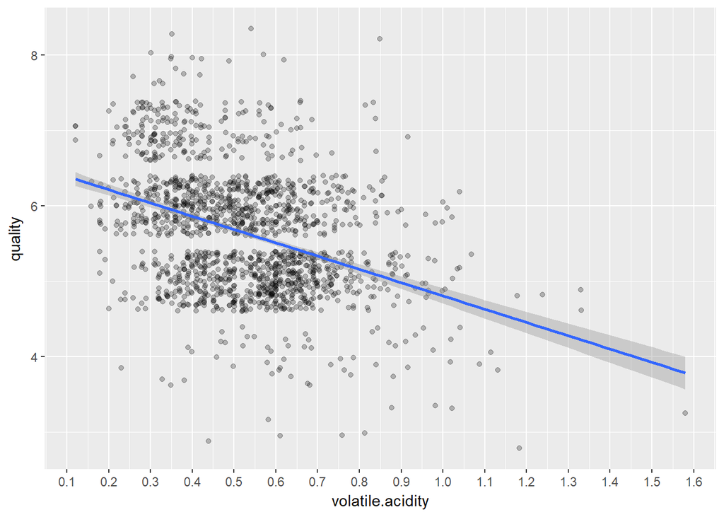

```r
# plota relação entre acidez volatil e qualidade
ggplot(baseVinho, aes(x = volatile.acidity, y = quality)) +
  geom_jitter(alpha = 0.25) +
  geom_smooth(method = "lm")+
  scale_x_continuous(breaks=seq(0, 2, 0.1))
```

Verifica-se a reta decrescente entre qualidade e volatilidade acida com correlação igual a -0.39.

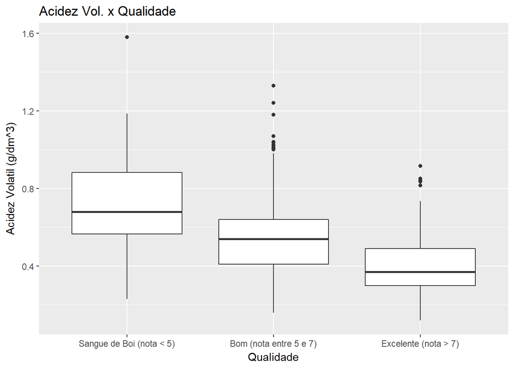

```r
# plotagem do qualidade x acidez volatil separando por classificação
p2 <- ggplot(data = baseVinho) +
  ylab('Acidez Volatil (g/dm^3)') +
  xlab('Qualidade') +
  geom_boxplot( aes(x = classificacao,
               y = volatile.acidity)) +
  scale_x_discrete(labels = c("sangue de boi" = "Sangue de Boi (nota < 5)",
                                        "bom" = "Bom (nota entre 5 e 7)",
                                  "excelente" = "Excelente (nota > 7)")) +
  ggtitle('Acidez Vol. x Qualidade')

p2
```

Pelo grafico de bloxpot fica mais visivel que em geral, os vinhos excelentes possuem menos acidez volatil com mediana igual a 0.37 contra 0.68 e 0.54, media com 0.4 contra 0.7 e 0.5 de acordo com a tabela a seguir.

```r
# estatistica dos boxplox
favstats(~baseVinho$volatile.acidity | baseVinho$classificacao, data = baseVinho)
```

```
##   baseVinho$classificacao  min    Q1 median     Q3   max      mean
## 1           sangue de boi 0.23 0.565   0.68 0.8825 1.580 0.7242063
## 2                     bom 0.16 0.410   0.54 0.6400 1.330 0.5385595
## 3               excelente 0.12 0.300   0.37 0.4900 0.915 0.4055300
##          sd    n missing
## 1 0.2479695   63       0
## 2 0.1676790 1319       0
## 3 0.1449627  217       0
```

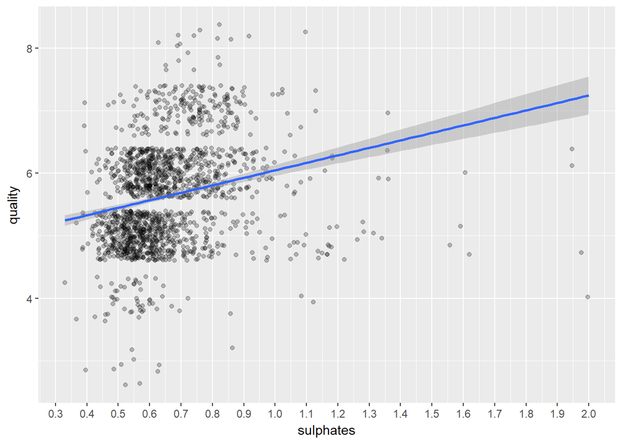

```r
#plota grafico sulfato x qualidade
ggplot(baseVinho, aes(x = sulphates, y = quality)) +
  geom_jitter(alpha = 0.25) +
  geom_smooth(method = "lm")+
  scale_x_continuous(breaks=seq(0, 2, 0.1))
```

Observa-se uma pequena inclinação da reta azul com o aumento da qualidade na medida que há um aumento no sulfato com correlação igual a 0.25.

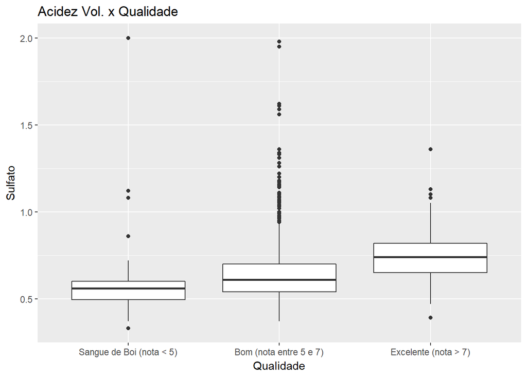

```r
# plotagem do qualidade x acidez volatil separando por classificação
p2 <- ggplot(data = baseVinho) +
  ylab('Sulfato') +
  xlab('Qualidade') +
  geom_boxplot( aes(x = classificacao,
               y = sulphates)) +
  scale_x_discrete(labels = c("sangue de boi" = "Sangue de Boi (nota < 5)",
                                        "bom" = "Bom (nota entre 5 e 7)",
                                  "excelente" = "Excelente (nota > 7)")) +
  ggtitle('Acidez Vol. x Qualidade')
p2
```

Ve-se que nos quartils de vinhos excelente eles em geral possuem mais sulfato(média de 0.74 contra 0.59 e 0.64), porém outiers de alta quantidade de sulfato com qualidade entre 5 e 7, como vemos na tabela a seguir.

```r
# estatistica dos boxplox
favstats(~baseVinho$sulphates | baseVinho$classificacao, data = baseVinho)
```

```
##   baseVinho$classificacao  min    Q1 median   Q3  max      mean        sd
## 1           sangue de boi 0.33 0.495   0.56 0.60 2.00 0.5922222 0.2243230
## 2                     bom 0.37 0.540   0.61 0.70 1.98 0.6472631 0.1673339
## 3               excelente 0.39 0.650   0.74 0.82 1.36 0.7434562 0.1340382
##      n missing
## 1   63       0
## 2 1319       0
## 3  217       0
```

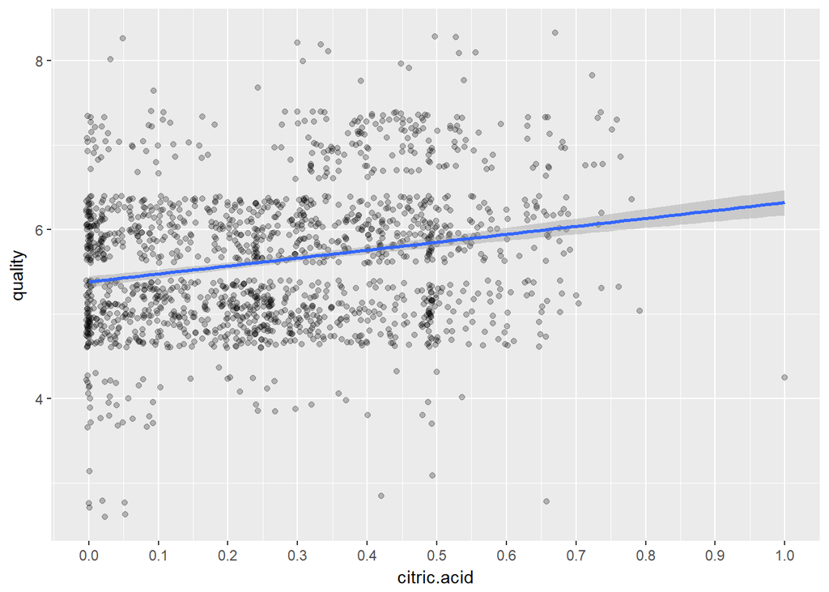

```r
# plota qualidade x acido citrico
ggplot(baseVinho, aes(x = citric.acid, y = quality)) +
  geom_jitter(alpha = 0.25) +
  geom_smooth(method = "lm")+
  scale_x_continuous(breaks=seq(0, 2, 0.1))
```

Verifica-se que na medida que a correlação cai, a reta azul é menos inclinada com correlação igual a 0.23.

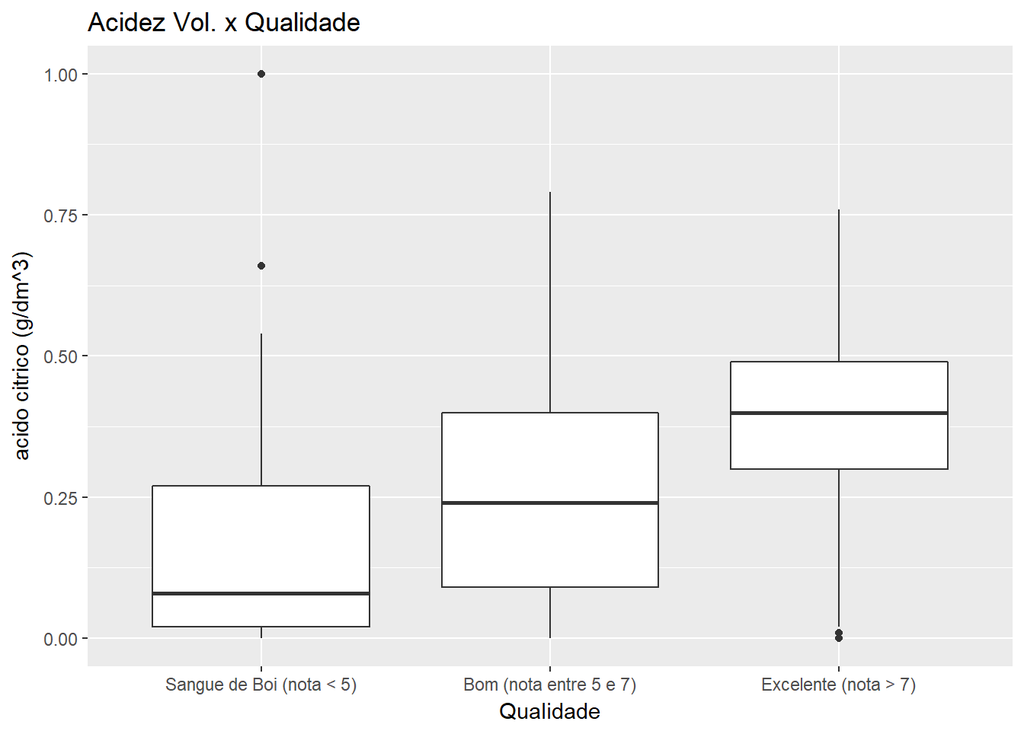

```r
# plotagem do qualidade x acido citrico separando por classificação
p2 <- ggplot(data = baseVinho) +
  ylab('acido citrico (g/dm^3)') +
  xlab('Qualidade') +
  geom_boxplot( aes(x = classificacao,
               y = citric.acid)) +
  scale_x_discrete(labels = c("sangue de boi" = "Sangue de Boi (nota < 5)",
                                        "bom" = "Bom (nota entre 5 e 7)",
                                  "excelente" = "Excelente (nota > 7)")) +
  ggtitle('Acidez Vol. x Qualidade')
p2
```

Nota-se pelos quartis que os vinhos excelentes possuem maior concentração de acido citrico com média igual a 0.37 contra 0.17 e 0.25 de acordo com a tabela abaixo.

```r
# estatistica dos boxplox
favstats(~baseVinho$citric.acid | baseVinho$classificacao, data = baseVinho)
```

```
##   baseVinho$classificacao min   Q1 median   Q3  max      mean        sd
## 1           sangue de boi   0 0.02   0.08 0.27 1.00 0.1736508 0.2074056
## 2                     bom   0 0.09   0.24 0.40 0.79 0.2582638 0.1879946
## 3               excelente   0 0.30   0.40 0.49 0.76 0.3764977 0.1944382
##      n missing
## 1   63       0
## 2 1319       0
## 3  217       0
```

Vamos verificar a correlação entre o ph e um acido.

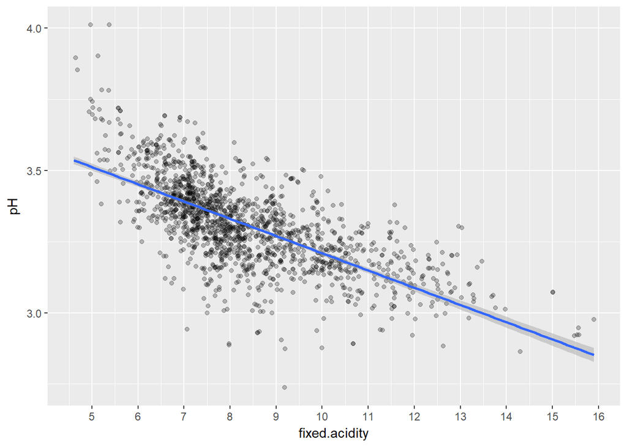

```r
#plota ph x acidez fixa
ggplot(baseVinho, aes(x = fixed.acidity, y = pH)) +
  geom_jitter(alpha = 0.25) +
  geom_smooth(method = "lm")+
  scale_x_continuous(breaks=seq(0, 16, 1))
```

verificamos agora a relação entre qualidade e PH.

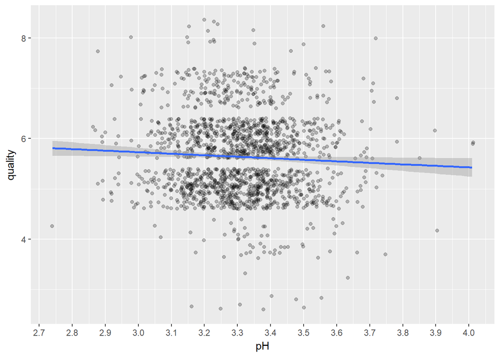

```r
#plota sulfato x qulaidade
ggplot(baseVinho, aes(x = pH, y = quality)) +
  geom_jitter(alpha = 0.25) +
  geom_smooth(method = "lm")+
  scale_x_continuous(breaks=seq(0, 4, 0.1))
```

Verificamos a baixa e quase nula relação entre PH e Qualidade com valor igual a -0.06.